# titanic_analysis_02

### Description[Titanic](https://www.kaggle.com/c/titanic)

The sinking of the RMS Titanic is one of the most infamous shipwrecks in history. On April 15, 1912, during her maiden voyage, the Titanic sank after colliding with an iceberg, killing 1502 out of 2224 passengers and crew. This sensational tragedy shocked the international community and led to better safety regulations for ships.

One of the reasons that the shipwreck led to such loss of life was that there were not enough lifeboats for the passengers and crew. Although there was some element of luck involved in surviving the sinking, some groups of people were more likely to survive than others, such as women, children, and the upper-class.

**Before analyzing the data, I want to see the data first.**  
Using pandas to load the data, and show some information of the data.

```python
import pandas as pd
import numpy as np
from pandas import Series, DataFrame

data_titanic = pd.read_csv("./titanic_data.csv")
data_titanic.info()
```

```
<class 'pandas.core.frame.DataFrame'>
RangeIndex: 891 entries, 0 to 890
Data columns (total 12 columns):
PassengerId    891 non-null int64
Survived       891 non-null int64
Pclass         891 non-null int64
Name           891 non-null object
Sex            891 non-null object
Age            714 non-null float64
SibSp          891 non-null int64
Parch          891 non-null int64
Ticket         891 non-null object
Fare           891 non-null float64
Cabin          204 non-null object
Embarked       889 non-null object
dtypes: float64(2), int64(5), object(5)
memory usage: 83.6+ KB
```

Obviously, there are some information I can get.

- 891 passangers in total
- Age some data lost, only 714
- Cabin even less, only 204  
  But I want to see more about the data, so I use the built-in function describe to show me the description:

```python
data_titanic.describe()
```

|  | PassengerId | Survived | Pclass | Age | SibSp | Parch | Fare |
| --- | --- | --- | --- | --- | --- | --- | --- |
| count | 891.000000 | 891.000000 | 891.000000 | 714.000000 | 891.000000 | 891.000000 | 891.000000 |
| mean | 446.000000 | 0.383838 | 2.308642 | 29.699118 | 0.523008 | 0.381594 | 32.204208 |
| std | 257.353842 | 0.486592 | 0.836071 | 14.526497 | 1.102743 | 0.806057 | 49.693429 |
| min | 1.000000 | 0.000000 | 1.000000 | 0.420000 | 0.000000 | 0.000000 | 0.000000 |
| 25% | 223.500000 | 0.000000 | 2.000000 | NaN | 0.000000 | 0.000000 | 7.910400 |
| 50% | 446.000000 | 0.000000 | 3.000000 | NaN | 0.000000 | 0.000000 | 14.454200 |
| 75% | 668.500000 | 1.000000 | 3.000000 | NaN | 1.000000 | 0.000000 | 31.000000 |
| max | 891.000000 | 1.000000 | 3.000000 | 80.000000 | 8.000000 | 6.000000 | 512.329200 |

```
WARNING: pylab import has clobbered these variables: ['axes']
`%matplotlib` prevents importing * from pylab and numpy
```

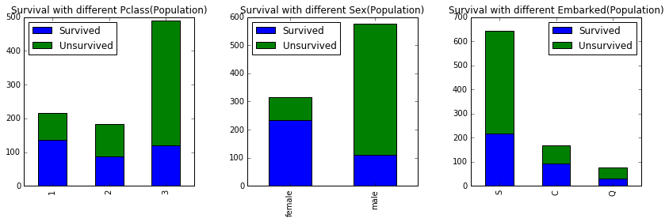

```python
%pylab inline
import matplotlib.pyplot as plt
fig = plt.figure()

fig, axes = plt.subplots(nrows=1, ncols=3)

#Draw graphs in a single one
Survived_0 = data_titanic.Pclass[data_titanic.Survived == 0].value_counts()
Survived_1 = data_titanic.Pclass[data_titanic.Survived == 1].value_counts()
df1=pd.DataFrame({u'Survived':Survived_1, u'Unsurvived':Survived_0})
df1.plot(kind='bar', ax=axes[0], figsize=(12, 4), title="Survival with different Pclass(Population)", stacked=True)


Survived_0 = data_titanic.Sex[data_titanic.Survived == 0].value_counts()
Survived_1 = data_titanic.Sex[data_titanic.Survived == 1].value_counts()
df2=pd.DataFrame({u'Survived':Survived_1, u'Unsurvived':Survived_0})
df2.plot(kind='bar', ax=axes[1], figsize=(12, 4), title="Survival with different Sex(Population)", stacked=True)


Survived_0 = data_titanic.Embarked[data_titanic.Survived == 0].value_counts()
Survived_1 = data_titanic.Embarked[data_titanic.Survived == 1].value_counts()
df3=pd.DataFrame({u'Survived':Survived_1, u'Unsurvived':Survived_0})
df3.plot(kind='bar', ax=axes[2], figsize=(12, 4), title="Survival with different Embarked(Population)", stacked=True)

plt.tight_layout()
```

I make three figures about survival from Pclass, Sex and Embarked(because the ranges of Age, Sibsp, Parch and Fare are so large that I should deal with the data first)

First, I want to deal with the data of Age.  
I want to see the the distribution of passangers' age, so I draw the dense graph as follows:

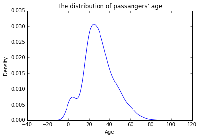

```python
data_titanic.Age.plot(kind='kde')
plt.xlabel(u"Age")
plt.ylabel(u"Density")
plt.title(u"The distribution of passangers' age")
plt.show()
```

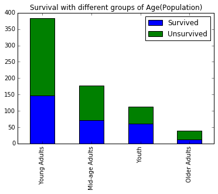

```python
def age_adjusted(age):
    if age < 18:
        return 'Youth'
    elif age < 36:
        return 'Young Adults'
    elif age < 56:
        return 'Mid-age Adults'
    elif age >= 56:
        return 'Older Adults'

age_group = pd.DataFrame(data_titanic.Age.apply(age_adjusted))
age_group.columns = ['GroupAge']

titanic_final = pd.concat([data_titanic, age_group], axis=1)

Survived_0 = titanic_final.GroupAge[titanic_final.Survived == 0].value_counts()
Survived_1 = titanic_final.GroupAge[titanic_final.Survived == 1].value_counts()
df_age=pd.DataFrame({u'Survived':Survived_1, u'Unsurvived':Survived_0})
df_age.plot(kind='bar', title="Survival with different groups of Age(Population)", stacked=True)
plt.show()
```

It seems that youth people get higher opportunities to survive at last, so age is a notable character, it should be discussed deeper later.

Second, I want to deal with the data of Sibsp.  
Maybe there is a connection between the number of sibsp and survival, so I grouped it.

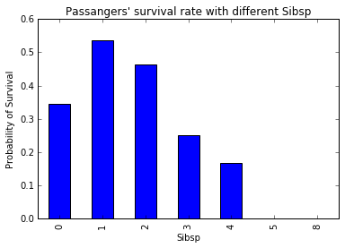

```python
g_survived = data_titanic[data_titanic.Survived == 1].groupby(['SibSp'])
g_total = data_titanic.groupby(['SibSp'])
df = pd.DataFrame(g_survived.count()['PassengerId'] / g_total.count()['PassengerId']).fillna(value=0)
df.PassengerId.plot(kind='bar')
plt.xlabel(u"Sibsp")
plt.ylabel(u"Probability of Survival")
plt.title(u"Passangers' survival rate with different Sibsp")
plt.show()
```

From the diagram above, we can see that with the precondition of having sibsp, the number of SibSp growing, the probability of survival is getting less, maybe just because those having many sibsp considering too much in the disaster, they wanted to find their family first that they spent too much time for survival.  
Third, I deal with the data of Parch.

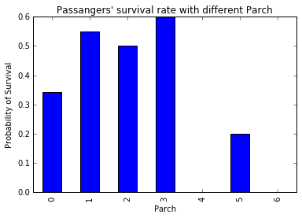

```python
g_survived = data_titanic[data_titanic.Survived == 1].groupby(['Parch'])
g_total = data_titanic.groupby(['Parch'])
df = pd.DataFrame(g_survived.count()['PassengerId'] / g_total.count()['PassengerId']).fillna(value=0)
df.PassengerId.plot(kind='bar')
plt.xlabel(u"Parch")
plt.ylabel(u"Probability of Survival")
plt.title(u"Passangers' survival rate with different Parch")
plt.show()
```

It's quite difficult to see the relationship, so I skipped this one.  
Then I deal with Fare. With a high standard deviation, so I want to standardize data first. [use preprocessing.StandardScaler()](http://scikit-learn.org/stable/modules/generated/sklearn.preprocessing.StandardScaler.html#sklearn.preprocessing.StandardScaler)

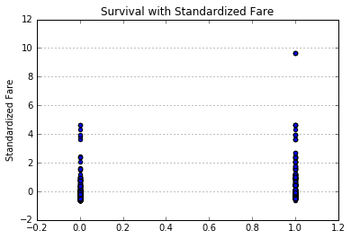

```python
from sklearn import preprocessing
scaler = preprocessing.StandardScaler()
fare_scale_param = scaler.fit(titanic_final['Fare'])
titanic_final['FareScaled'] = scaler.fit_transform(titanic_final['Fare'], fare_scale_param)
plt.scatter(titanic_final.Survived, titanic_final.FareScaled)
plt.ylabel(u"Standardized Fare")
plt.title(u"Survival with Standardized Fare")
plt.grid(b=True, which='major', axis='y')
```

It seems there is no significant connection between Fare and Survival.  
Finally I deal with Cabin. Since the absence of information, no significant connection between survival and Cabin number in addition, I set Cabin 'Yes' or 'No' to identify the relationship.

```python
def set_cabin(data):
    data.loc[(data.Cabin.notnull()), 'Cabin'] = "Yes"
    data.loc[(data.Cabin.isnull()), 'Cabin'] = "No"
    return data

titanic_final = set_cabin(titanic_final) # only be run once, if run again, the function will set 'No' to 'Yes'
```

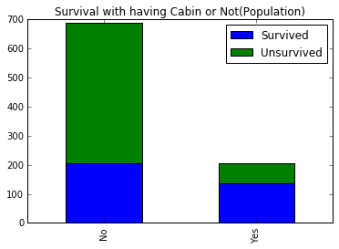

```python
Survived_0 = titanic_final.Cabin[titanic_final.Survived == 0].value_counts()
Survived_1 = titanic_final.Cabin[titanic_final.Survived == 1].value_counts()
df=pd.DataFrame({u'Survived':Survived_1, u'Unsurvived':Survived_0})
df.plot(kind='bar', stacked=True, title='Survival with having Cabin or Not(Population)')

plt.show()
```

From the chart, I found that with a Cabin, the survival probability is higher. From the above analysis with a single attribute, I found that if a person met the condition as follows, he/she would get higher probability to survival

- a first-class ticket
- a female
- was young
- had a Cabin
- had few Sibsp(While the data is small when one had more sibsp, so there was random error)  
  Now, I want to conbine some attributes to make a more significate result.  
  How is the conbination of Pclass and Sex going?  
  How is Pclass and Age?  
  And Pclass with a Cabin?

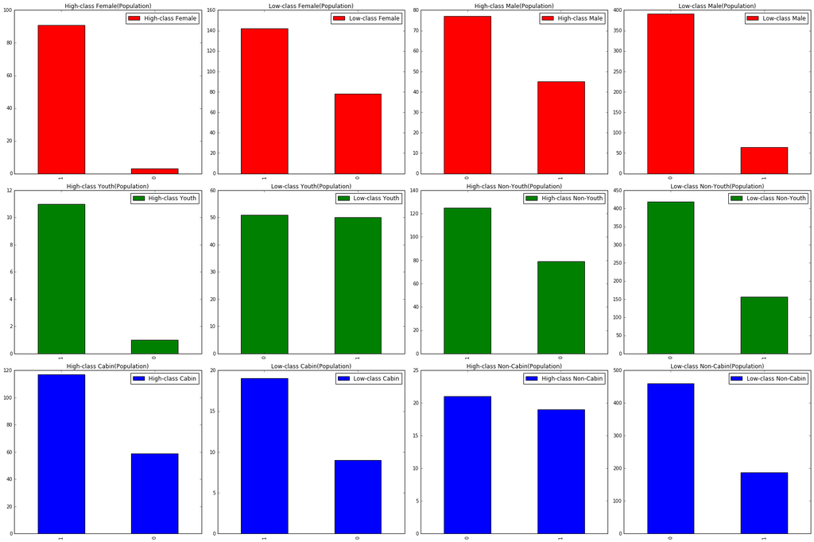

```python
fig, axes = plt.subplots(nrows=3, ncols=4)

#Draw graphs in a single one
df0 = pd.DataFrame(titanic_final.Survived[titanic_final.Sex == 'female'][titanic_final.Pclass == 1].value_counts())
df0.columns = ['High-class Female']
df0.plot(kind='bar', ax=axes[0][0], figsize=(24, 16), color='r', title="High-class Female(Population)")

df1 = pd.DataFrame(titanic_final.Survived[titanic_final.Sex == 'female'][titanic_final.Pclass != 1].value_counts())
df1.columns = ['Low-class Female']
df1.plot(kind='bar', ax=axes[0][1], figsize=(24, 16), color='r', title="Low-class Female(Population)")

df2 = pd.DataFrame(titanic_final.Survived[titanic_final.Sex == 'male'][titanic_final.Pclass == 1].value_counts())
df2.columns = ['High-class Male']
df2.plot(kind='bar', ax=axes[0][2], figsize=(24, 16), color='r', title="High-class Male(Population)")

df3 = pd.DataFrame(titanic_final.Survived[titanic_final.Sex == 'male'][titanic_final.Pclass != 1].value_counts())
df3.columns = ['Low-class Male']
df3.plot(kind='bar', ax=axes[0][3], figsize=(24, 16), color='r', title="Low-class Male(Population)")

df4 = pd.DataFrame(titanic_final.Survived[titanic_final.GroupAge == 'Youth'][titanic_final.Pclass == 1].value_counts())
df4.columns = ['High-class Youth']
df4.plot(kind='bar', ax=axes[1][0], figsize=(24, 16), color='g', title="High-class Youth(Population)")

df5 = pd.DataFrame(titanic_final.Survived[titanic_final.GroupAge == 'Youth'][titanic_final.Pclass != 1].value_counts())
df5.columns = ['Low-class Youth']
df5.plot(kind='bar', ax=axes[1][1], figsize=(24, 16), color='g', title="Low-class Youth(Population)")

df6 = pd.DataFrame(titanic_final.Survived[titanic_final.GroupAge != 'Youth'][titanic_final.Pclass == 1].value_counts())
df6.columns = ['High-class Non-Youth']
df6.plot(kind='bar', ax=axes[1][2], figsize=(24, 16), color='g', title="High-class Non-Youth(Population)")

df7 = pd.DataFrame(titanic_final.Survived[titanic_final.GroupAge != 'Youth'][titanic_final.Pclass != 1].value_counts())
df7.columns = ['Low-class Non-Youth']
df7.plot(kind='bar', ax=axes[1][3], figsize=(24, 16), color='g', title="Low-class Non-Youth(Population)")

df8 = pd.DataFrame(titanic_final.Survived[titanic_final.Cabin == 'Yes'][titanic_final.Pclass == 1].value_counts())
df8.columns = ['High-class Cabin']
df8.plot(kind='bar', ax=axes[2][0], figsize=(24, 16), color='b', title="High-class Cabin(Population)")

df9 = pd.DataFrame(titanic_final.Survived[titanic_final.Cabin == 'Yes'][titanic_final.Pclass != 1].value_counts())
df9.columns = ['Low-class Cabin']
df9.plot(kind='bar', ax=axes[2][1], figsize=(24, 16), color='b', title="Low-class Cabin(Population)")

df10 = pd.DataFrame(titanic_final.Survived[titanic_final.Cabin == 'No'][titanic_final.Pclass == 1].value_counts())
df10.columns = ['High-class Non-Cabin']
df10.plot(kind='bar', ax=axes[2][2], figsize=(24, 16), color='b', title="High-class Non-Cabin(Population)")

df11 = pd.DataFrame(titanic_final.Survived[titanic_final.Cabin == 'No'][titanic_final.Pclass != 1].value_counts())
df11.columns = ['Low-class Non-Cabin']
df11.plot(kind='bar', ax=axes[2][3], figsize=(24, 16), color='b', title="Low-class Non-Cabin(Population)")

plt.tight_layout()
```

From the above graphs, we see that the advantages of attribution is superposed, while Female with first-class ticket or young people with first-class ticket has the highest probability to survive.